# Causal Impact Demonstration

Polly Ramsey Mangan

May 18, 2016

**CausalImpact** is an R package for determining Causal Inference using Bayesian structural time-series models. It was developed by Kay H. Brodersen, a data scientist at Google.

The package aims at determining the effect of a designed intervention on a time series. Many web initiatives can only be measured using an activation date, as opposed to a variable that persists for the entire timeline, like dollars spent. This model creates a Bayesian structural time-series model on the pre-intervention timeline based on a set of control time series, and forcasts this model to estimate how the response variable would change if the intervention never happened. This forecast is then compared to the actual post-intervention response varaibles to quantify the impact of the intervention.

More information and usage instructions can be found on [Google’s Github page](https://google.github.io/CausalImpact/CausalImpact.html).

This demonstration uses the CausalImpact package to measure the impact of one particular web initiative, *Program P*, on a select group of business websites. All data have been obfuscated for presentation purposes.

# Initialize

Install and load CausalImpact as well as other necessary packages.

```r
# Install and load package requred to clone directly from Github
#install.packages("devtools")
#library(devtools)

# Install and load CausalImpact package
#devtools::install_github("google/CausalImpact")
library(CausalImpact)

# Load all other necessary packages
set.seed(1986)
library(dplyr)
library(ggplot2)
```

# Load Dataset

The dataset is currently set up as two files. One file holds the web data for each account (organic visits as well as money spent on various web marketing channels), and the other contains only the *Program P* start dates.

For privacy purposes, all website names and dates have been changed and all visit and spend data have been obfuscated.

```r
# Read in web data
webdata <- read.csv(file = "~/Meetup/Web_data.csv", stringsAsFactors = FALSE)
webdata$weekEnding <- as.Date(webdata$weekEnding, format = "%m/%d/%y")
head(filter(webdata, accountName == "happyAlpaca"))
```

```
##   accountName weekEnding organicVisits paidSearchCost displayCost
## 1 happyAlpaca 2014-03-23      66.07744       291.0063     0.00000
## 2 happyAlpaca 2014-03-30      66.92631       316.9724     0.00000
## 3 happyAlpaca 2014-04-06      92.09239       279.6608     0.00000
## 4 happyAlpaca 2014-04-13      74.91219       222.6906     0.00000
## 5 happyAlpaca 2014-04-20      70.07834       299.8321    48.67717
## 6 happyAlpaca 2014-04-27      67.02129       252.0914    35.37635
##   premiumDisplayCost remarketingCost
## 1                  0       13.105963
## 2                  0       17.184689
## 3                  0       10.272296
## 4                  0        6.235327
## 5                  0       36.305020
## 6                  0       44.554661
```

```r
# Read in Program P start dates
startdates <- read.csv(file = "~/Meetup/Start_dates.csv", stringsAsFactors = FALSE)
startdates$startDate <- as.Date(startdates$startDate, format = "%m/%d/%y")
startdates
```

```
##     accountName  startDate
## 1 peacefulCamel 2015-06-03
## 2  elatedBaboon 2014-07-29
## 3    livelyDuck 2014-10-29
## 4   happyAlpaca 2014-10-14
```

Included in the dataset are four different websites, which will each be analyzed separately.

# Website 1: happyAlpaca.com

First, filter the dataset so it only includes the information for the website we are currently interested in.

```r
acctname_sample <- "happyAlpaca"

webdata_sample  <- webdata %>%
  filter(accountName == acctname_sample)

startdate <- startdates$startDate[startdates$accountName == acctname_sample]
```

The next step is to visualize the data we have to get an understanding of the account and how the web metrics changed throughout the timeline.

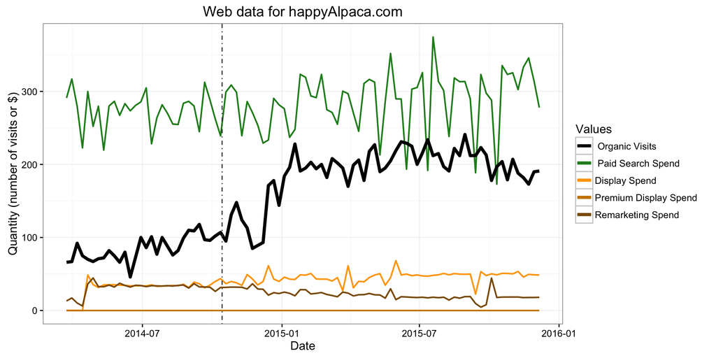

```r
ggplot(webdata_sample, aes(x = weekEnding)) +
  geom_line(aes(y = paidSearchCost, col = " Paid Search Spend"), size = .75) +
  geom_line(aes(y = displayCost, col = "Display Spend"), size = .75) +
  geom_line(aes(y = premiumDisplayCost, col = "Premium Display Spend"), size = .75) +
  geom_line(aes(y = remarketingCost, col = "Remarketing Spend"), size = .75) +
  geom_line(aes(y = organicVisits, col = " Organic Visits"), size = 1.5) +
  geom_vline(xintercept = as.numeric(startdate), linetype = 4, col = "gray25") +
  theme_bw() +
  labs(x = "Date",
       y = "Quantity (number of visits or $)",
       title = paste0("Web data for ", acctname_sample, ".com")) +
  scale_color_manual(name = "Values",
                     values = c(" Organic Visits"       = "black",
                                " Paid Search Spend"    = "forestgreen",
                                "Display Spend"         = "orange1",
                                "Premium Display Spend" = "orange3",
                                "Remarketing Spend"     = "orange4"))
```

For this website, the online advertising costs stay relatively constant throughout the entire timeline, and there is a noticeable increase in organic visits after the *Program P* intervention. In this case it is pretty clear without using Causal Impact that *Program P* has increased organic traffic, but statistical analysis will confirm the hypothesis.

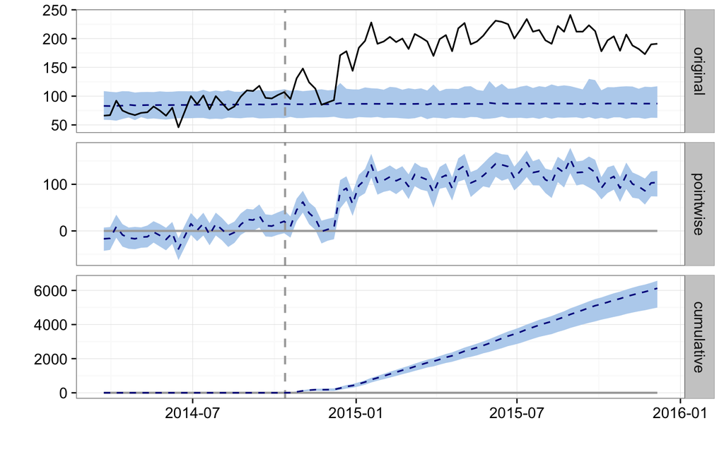

```r
# Convert to Zoo series - a great format for time series expecially if the observations are irregular
webdata_sample <- zoo(x = webdata_sample[ , c("organicVisits", "paidSearchCost", "displayCost",
                                              "premiumDisplayCost", "remarketingCost")],
                      order.by = webdata_sample[ , "weekEnding"])

# Create "Pre-period" and "Post-period" timelines to be inputted in the Causal Impact function
# Now that webdata_sample is a Zoo object we can utilize the start() and end() functions
pre.period  <- as.Date(c(start(webdata_sample), startdate - 1))
post.period <- as.Date(c(startdate, end(webdata_sample)))

# Run Causal Impact
impact      <- CausalImpact(webdata_sample, pre.period, post.period)
   # Seasonality component can be added to the model using the model argument nseasons if applicable

# Plot results
plot(impact)
```

This visualization is great for giving a high-level report on if *Program P* worked for this website or not. In addition, all of the Bayesian model specifications and results are available using the Causal Impact package.

```r
## Print numerical summary of analysis
summary(impact)
```

```
## Posterior inference {CausalImpact}
##
##                          Average       Cumulative
## Actual                   189           11330
## Prediction (s.d.)        87 (6.1)      5205 (368.1)
## 95% CI                   [79, 106]     [4764, 6336]
##
## Absolute effect (s.d.)   102 (6.1)     6125 (368.1)
## 95% CI                   [83, 109]     [4994, 6566]
##
## Relative effect (s.d.)   118% (7.1%)   118% (7.1%)
## 95% CI                   [96%, 126%]   [96%, 126%]
##
## Posterior tail-area probability p:   0.00111
## Posterior prob. of a causal effect:  99.88901%
##
## For more details, type: summary(impact, "report")
```

```r
## Print out full text-based report
summary(impact, "report")
```

[output not shown]

```r
## Print table with model values
impact$summary
```

```
##                Actual       Pred Pred.lower Pred.upper   Pred.sd AbsEffect
## Average      188.8355   86.74966   79.40384   105.6027   6.13419  102.0858
## Cumulative 11330.1284 5204.97952 4764.23030  6336.1623 368.05142 6125.1489
##            AbsEffect.lower AbsEffect.upper AbsEffect.sd RelEffect
## Average           83.23277        109.4316      6.13419  1.176786
## Cumulative      4993.96609       6565.8981    368.05142  1.176786
##            RelEffect.lower RelEffect.upper RelEffect.sd alpha           p
## Average          0.9594593        1.261465   0.07071141  0.05 0.001109878
## Cumulative       0.9594593        1.261465   0.07071141  0.05 0.001109878
```

# Website 2: elatedBaboon.com

```r
acctname_sample <- "elatedBaboon"
webdata_sample  <- webdata %>%
  filter(accountName == acctname_sample)
startdate <- startdates$startDate[startdates$accountName == acctname_sample]
```

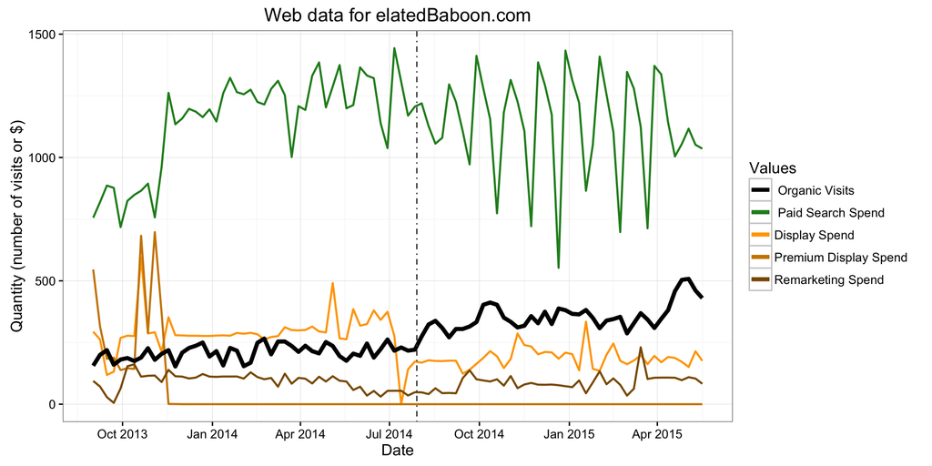

```r
ggplot(webdata_sample, aes(x = weekEnding)) +
  geom_line(aes(y = paidSearchCost, col = " Paid Search Spend"), size = .75) +
  geom_line(aes(y = displayCost, col = "Display Spend"), size = .75) +
  geom_line(aes(y = premiumDisplayCost, col = "Premium Display Spend"), size = .75) +
  geom_line(aes(y = remarketingCost, col = "Remarketing Spend"), size = .75) +
  geom_line(aes(y = organicVisits, col = " Organic Visits"), size = 1.5) +
  geom_vline(xintercept = as.numeric(startdate), linetype = 4, col = "gray25") +
  theme_bw() +
  labs(x = "Date",
       y = "Quantity (number of visits or $)",
       title = paste0("Web data for ", acctname_sample, ".com")) +
  scale_color_manual(name = "Values",
                     values = c(" Organic Visits"       = "black",
                                " Paid Search Spend"    = "forestgreen",
                                "Display Spend"         = "orange1",
                                "Premium Display Spend" = "orange3",
                                "Remarketing Spend"     = "orange4"))
```

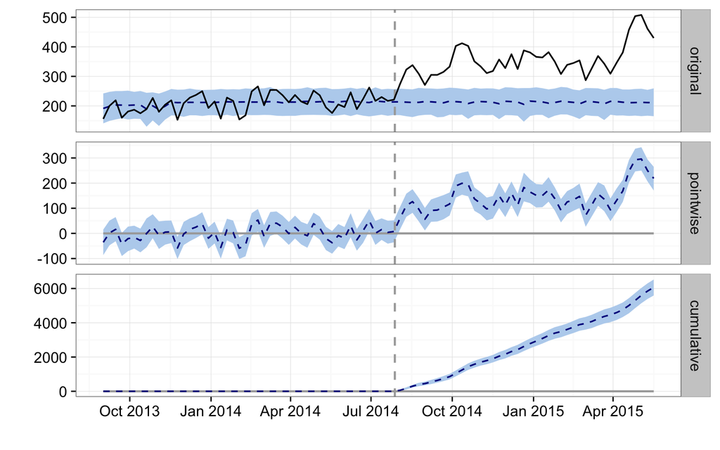

```r
webdata_sample <- zoo(x = webdata_sample[ , c("organicVisits", "paidSearchCost", "displayCost",
                                              "premiumDisplayCost", "remarketingCost")],
                      order.by = webdata_sample[ , "weekEnding"])
pre.period  <- as.Date(c(start(webdata_sample), startdate - 1))
post.period <- as.Date(c(startdate, end(webdata_sample)))
impact      <- CausalImpact(webdata_sample, pre.period, post.period)
plot(impact)
```

This website is less consistent with their Paid Search and Display advertising, so it is not as clear from the first visualization if *Program P* had a meaningful impact. However, the Causal Impact visualization makes the effect very clear and the causal effect is statistically significant.

# Website 3: peacefulCamel.com

```r
acctname_sample <- "peacefulCamel"
webdata_sample  <- webdata %>%
  filter(accountName == acctname_sample)
startdate <- startdates$startDate[startdates$accountName == acctname_sample]
```

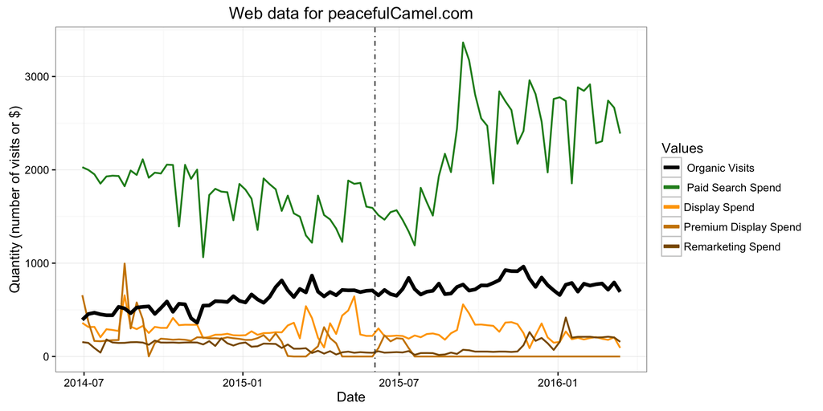

```r
ggplot(webdata_sample, aes(x = weekEnding)) +
  geom_line(aes(y = paidSearchCost, col = " Paid Search Spend"), size = .75) +
  geom_line(aes(y = displayCost, col = "Display Spend"), size = .75) +
  geom_line(aes(y = premiumDisplayCost, col = "Premium Display Spend"), size = .75) +
  geom_line(aes(y = remarketingCost, col = "Remarketing Spend"), size = .75) +
  geom_line(aes(y = organicVisits, col = " Organic Visits"), size = 1.5) +
  geom_vline(xintercept = as.numeric(startdate), linetype = 4, col = "gray25") +
  theme_bw() +
  labs(x = "Date",
       y = "Quantity (number of visits or $)",
       title = paste0("Web data for ", acctname_sample, ".com")) +
  scale_color_manual(name = "Values",
                     values = c(" Organic Visits"       = "black",
                                " Paid Search Spend"    = "forestgreen",
                                "Display Spend"         = "orange1",
                                "Premium Display Spend" = "orange3",
                                "Remarketing Spend"     = "orange4"))
```

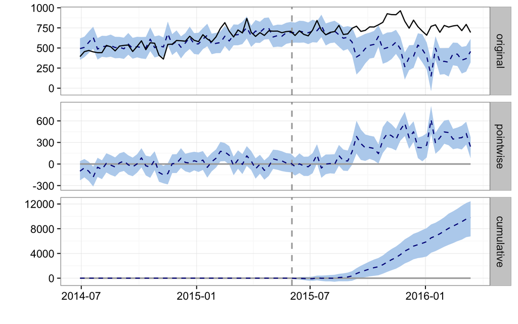

```r
webdata_sample <- zoo(x = webdata_sample[ , c("organicVisits", "paidSearchCost", "displayCost",
                                              "premiumDisplayCost", "remarketingCost")],
                      order.by = webdata_sample[ , "weekEnding"])
pre.period  <- as.Date(c(start(webdata_sample), startdate - 1))
post.period <- as.Date(c(startdate, end(webdata_sample)))
impact      <- CausalImpact(webdata_sample, pre.period, post.period)
plot(impact)
```

The success story here isn’t told by a large increase in Organic Visits; organic traffic only increases slightly after *Program P* is activated. Instead, Organic Visits **holds strong even with a large increase in Paid Search spend, which many times cannibalizes organic traffic**. Sometimes when Paid Search spend is increased substantially, part of the visiting population who would have found the site organically will instead use a Paid Search link, causing a decrease in organic traffic.

This website is a perfect example of why Causal Impact is useful. Simply looking at whether there is an increase in organic traffic does not always tell the whole story.

# Website 4: livelyDuck.com

```r
acctname_sample <- "livelyDuck"
webdata_sample  <- webdata %>%
  filter(accountName == acctname_sample)
startdate <- startdates$startDate[startdates$accountName == acctname_sample]
```

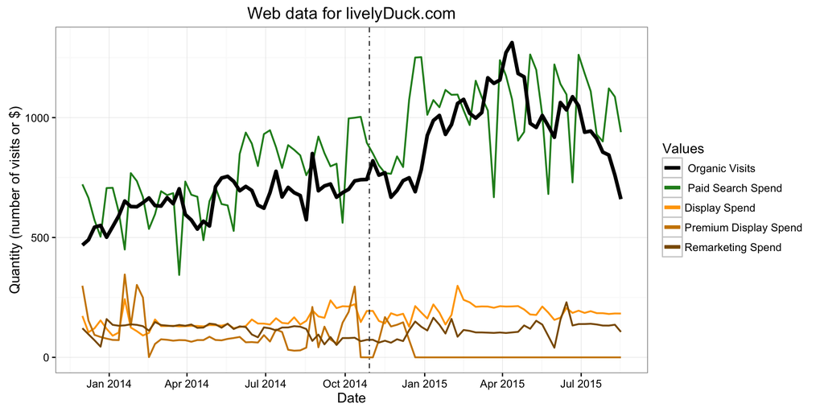

```r
ggplot(webdata_sample, aes(x = weekEnding)) +
  geom_line(aes(y = paidSearchCost, col = " Paid Search Spend"), size = .75) +
  geom_line(aes(y = displayCost, col = "Display Spend"), size = .75) +
  geom_line(aes(y = premiumDisplayCost, col = "Premium Display Spend"), size = .75) +
  geom_line(aes(y = remarketingCost, col = "Remarketing Spend"), size = .75) +
  geom_line(aes(y = organicVisits, col = " Organic Visits"), size = 1.5) +
  geom_vline(xintercept = as.numeric(startdate), linetype = 4, col = "gray25") +
  theme_bw() +
  labs(x = "Date",
       y = "Quantity (number of visits or $)",
       title = paste0("Web data for ", acctname_sample, ".com")) +
  scale_color_manual(name = "Values",
                     values = c(" Organic Visits"       = "black",
                                " Paid Search Spend"    = "forestgreen",
                                "Display Spend"         = "orange1",
                                "Premium Display Spend" = "orange3",
                                "Remarketing Spend"     = "orange4"))
```

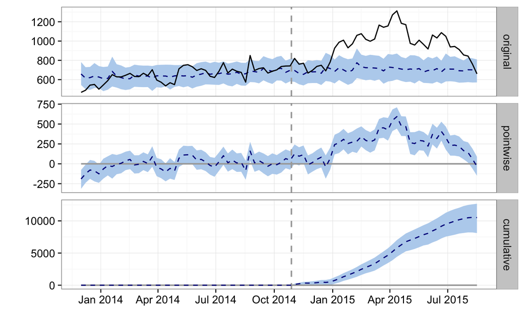

```r
webdata_sample <- zoo(x = webdata_sample[ , c("organicVisits", "paidSearchCost", "displayCost",
                                              "premiumDisplayCost", "remarketingCost")],
                      order.by = webdata_sample[ , "weekEnding"])
pre.period  <- as.Date(c(start(webdata_sample), startdate - 1))
post.period <- as.Date(c(startdate, end(webdata_sample)))
impact      <- CausalImpact(webdata_sample, pre.period, post.period)
plot(impact)
```

This is an example of a website where *Program P* had waning impact. The *Program P* intervention caused organic traffic to increase for the first few months, but now that it has been activated for a while the effects are diminishing. In fact, the organic traffic levels are now at pre-intervention levels.

# Conclusion

CausalImpact is easy to use, provides great visualizations that can be easily explained to non-technical stakeholders, and can be manually adjusted if flexibility is desired. This package successfully simplifies the process of inferring causal effects in a way that any proficient R user can utilize. It is a great example of a statistical package that was made to be shared on this open source platform.